# Analisis Pengaruh Rental Duration dan Replacement Cost terhadap Rental Rate pada Database Sakila berdasarkan Rating Film

Fa Naadaa Haqq Hastawan - M0724008

2026-05-24

```r
library(DBI)
library(dplyr)
library(ggplot2)
library(tidyr)
library(lmtest)
library(car)
library(knitr)
library(kableExtra)
```

# 1 Pendahuluan

## 1.1 Latar Belakang

Industri penyewaan film merupakan salah satu segmen bisnis hiburan yang memiliki dinamika menarik dalam penentuan harga. Dalam pengelolaan bisnis rental film, dua faktor yang secara langsung memengaruhi *rental rate* (harga sewa) adalah **durasi sewa** (*rental duration*) dan **biaya penggantian** (*replacement cost*) dari film tersebut.

Namun, efektivitas kedua faktor tersebut tidak selalu seragam di setiap segmen film. **Rating film** — yang mencerminkan segmen usia penonton dan kualitas konten — dapat memoderasi hubungan antara durasi sewa dan biaya penggantian terhadap harga sewa yang ditetapkan.

Database **Sakila** merupakan database sampel MySQL yang merepresentasikan bisnis rental DVD fiktif. Database ini mencakup informasi lengkap mengenai film, kategori, aktor, pelanggan, dan transaksi sewa yang memungkinkan analisis multivariat secara menyeluruh.

# 2 Deskripsi Data

## 2.1 Koneksi Database dan Sumber Data

```r
con <- DBI::dbConnect(odbc::odbc(),
               Driver = "MySQL ODBC 9.6 ANSI Driver",
               Server = "127.0.0.1",
               Database = "sakila",
               UID = "root",
               PWD = "nadd1234",
               Port = 3306)
```

```r
query <- "
  SELECT
    f.film_id,
    f.title,
    f.rating,
    f.rental_duration,
    f.rental_rate,
    f.length        AS film_length,
    f.replacement_cost,
    c.name          AS category
  FROM film f
  JOIN film_category fc ON f.film_id = fc.film_id
  JOIN category      c  ON fc.category_id = c.category_id
"

df <- dbGetQuery(con, query)

cat("Jumlah baris :", nrow(df), "\n")
```

```
## Jumlah baris : 1000
```

```r
cat("Jumlah kolom :", ncol(df), "\n")
```

```
## Jumlah kolom : 8
```

```r
cat("Rating unik  :", paste(sort(unique(df$rating)), collapse = ", "), "\n")
```

```
## Rating unik  : G, NC-17, PG, PG-13, R
```

## 2.2 Deskripsi Variabel

Berikut adalah variabel-variabel yang digunakan dalam analisis ini:

```r
tbl_var <- data.frame(
  Variabel           = c("rental_duration", "replacement_cost",
                         "rental_rate", "film_length", "rating", "category"),
  Tipe               = c("Numerik", "Numerik", "Numerik",
                         "Numerik", "Kategorik", "Kategorik"),
  Keterangan         = c(
    "Durasi maksimum penyewaan film (dalam hari)",
    "Biaya penggantian jika film hilang/rusak (dalam USD)",
    "Harga sewa film per periode (dalam USD) — variabel respons",
    "Durasi film (dalam menit)",
    "Klasifikasi usia penonton: G, PG, PG-13, R, NC-17",
    "Genre film: Action, Comedy, Drama, dll."
  )
)

kable(tbl_var, caption = "Deskripsi Variabel Analisis") %>%
  kable_styling(bootstrap_options = c("striped", "hover"), full_width = FALSE)
```

Deskripsi Variabel Analisis

| Variabel | Tipe | Keterangan |
| --- | --- | --- |
| rental_duration | Numerik | Durasi maksimum penyewaan film (dalam hari) |
| replacement_cost | Numerik | Biaya penggantian jika film hilang/rusak (dalam USD) |
| rental_rate | Numerik | Harga sewa film per periode (dalam USD) — variabel respons |
| film_length | Numerik | Durasi film (dalam menit) |
| rating | Kategorik | Klasifikasi usia penonton: G, PG, PG-13, R, NC-17 |
| category | Kategorik | Genre film: Action, Comedy, Drama, dll. |

## 2.3 Pemeriksaan Missing Value

```r
missing_check <- data.frame(
  Variabel = names(df),
  Missing  = colSums(is.na(df))
)
missing_check <- missing_check[missing_check$Missing > 0, ]

if (nrow(missing_check) == 0) {
  cat("Tidak ditemukan missing value pada seluruh variabel.\n")
} else {
  kable(missing_check) %>%
    kable_styling(bootstrap_options = c("striped", "hover"), full_width = FALSE)
}
```

```
## Tidak ditemukan missing value pada seluruh variabel.
```

## 2.4 Statistik Deskriptif

```r
vars_num <- df %>% select(rental_duration, replacement_cost, rental_rate, film_length)

stat_desc <- data.frame(
  Variabel = names(vars_num),
  Min      = round(sapply(vars_num, min),    2),
  Q1       = round(sapply(vars_num, quantile, 0.25), 2),
  Median   = round(sapply(vars_num, median), 2),
  Mean     = round(sapply(vars_num, mean),   2),
  Q3       = round(sapply(vars_num, quantile, 0.75), 2),
  Max      = round(sapply(vars_num, max),    2),
  SD       = round(sapply(vars_num, sd),     2)
)

kable(stat_desc,
      caption    = "Statistik Deskriptif Variabel Numerik",
      col.names  = c("Variabel", "Min", "Q1", "Median", "Mean", "Q3", "Max", "Std. Dev")) %>%
  kable_styling(bootstrap_options = c("striped", "hover"), full_width = FALSE)
```

Statistik Deskriptif Variabel Numerik

|  | Variabel | Min | Q1 | Median | Mean | Q3 | Max | Std. Dev |
| --- | --- | --- | --- | --- | --- | --- | --- | --- |
| rental_duration | rental_duration | 3.00 | 4.00 | 5.00 | 4.98 | 6.00 | 7.00 | 1.41 |
| replacement_cost | replacement_cost | 9.99 | 14.99 | 19.99 | 19.98 | 24.99 | 29.99 | 6.05 |
| rental_rate | rental_rate | 0.99 | 0.99 | 2.99 | 2.98 | 4.99 | 4.99 | 1.65 |
| film_length | film_length | 46.00 | 80.00 | 114.00 | 115.27 | 149.25 | 185.00 | 40.43 |

Distribusi *rental_rate* menunjukkan nilai minimum $\min = 0.99$ dan nilai maksimum $\max = 4.99$, dengan rata-rata $\bar{x} = 2.98$ dan standar deviasi $s = 1.65$. Rentang yang cukup sempit ini mengindikasikan bahwa harga sewa dalam database Sakila sudah terstandarisasi, namun tetap terdapat variasi yang dapat dijelaskan oleh karakteristik film.

# 3 Perbedaan Dinamika *Rental Rate* Berdasarkan Rating Film

## 3.1 Eksplorasi Awal

Rata-rata *Rental Rate* berdasarkan **Rating** dan **Kategori Film**:

```r
rate_tbl <- df %>%
  group_by(rating, category) %>%
  summarise(
    N             = n(),
    Mean_Rate     = round(mean(rental_rate), 2),
    SD_Rate       = round(sd(rental_rate),   2),
    .groups       = "drop"
  ) %>%
  pivot_wider(names_from = rating,
              values_from = c(N, Mean_Rate, SD_Rate))

kable(rate_tbl,
      caption = "Rata-rata Rental Rate per Kategori Film dan Rating") %>%
  kable_styling(bootstrap_options = c("striped", "hover", "responsive"),
                full_width = FALSE)
```

Rata-rata Rental Rate per Kategori Film dan Rating

| category | N_G | N_NC-17 | N_PG | N_PG-13 | N_R | Mean_Rate_G | Mean_Rate_NC-17 | Mean_Rate_PG | Mean_Rate_PG-13 | Mean_Rate_R | SD_Rate_G | SD_Rate_NC-17 | SD_Rate_PG | SD_Rate_PG-13 | SD_Rate_R |
| --- | --- | --- | --- | --- | --- | --- | --- | --- | --- | --- | --- | --- | --- | --- | --- |
| Action | 18 | 12 | 9 | 11 | 14 | 2.77 | 1.82 | 2.55 | 2.99 | 2.99 | 1.93 | 1.34 | 1.33 | 1.79 | 1.57 |
| Animation | 13 | 15 | 11 | 19 | 8 | 2.68 | 3.12 | 3.17 | 2.67 | 2.24 | 1.60 | 1.60 | 1.40 | 1.53 | 1.83 |
| Children | 10 | 12 | 15 | 14 | 9 | 3.19 | 2.32 | 3.26 | 3.13 | 2.32 | 1.48 | 1.78 | 1.67 | 1.66 | 1.41 |
| Classics | 11 | 9 | 10 | 13 | 14 | 2.08 | 2.55 | 3.39 | 3.30 | 2.42 | 1.04 | 1.67 | 1.58 | 1.80 | 1.65 |
| Comedy | 11 | 11 | 16 | 12 | 8 | 2.63 | 3.17 | 2.87 | 3.66 | 3.74 | 1.75 | 1.66 | 1.54 | 1.30 | 1.83 |
| Documentary | 14 | 13 | 16 | 12 | 13 | 2.28 | 2.99 | 2.62 | 3.16 | 2.37 | 1.68 | 1.63 | 1.67 | 1.80 | 1.50 |
| Drama | 12 | 15 | 7 | 22 | 6 | 3.49 | 3.52 | 2.42 | 2.72 | 2.66 | 1.51 | 1.77 | 1.90 | 1.88 | 1.51 |
| Family | 10 | 14 | 18 | 11 | 16 | 2.99 | 2.85 | 2.99 | 2.81 | 2.24 | 1.33 | 1.66 | 1.94 | 1.40 | 1.44 |
| Foreign | 13 | 12 | 14 | 19 | 15 | 2.37 | 3.66 | 2.56 | 3.62 | 3.12 | 1.50 | 1.30 | 1.40 | 1.64 | 1.77 |
| Games | 11 | 16 | 5 | 14 | 15 | 3.35 | 2.49 | 4.19 | 3.56 | 3.39 | 1.75 | 1.55 | 1.79 | 1.65 | 1.88 |
| Horror | 9 | 7 | 12 | 14 | 14 | 2.77 | 2.13 | 3.16 | 2.85 | 3.70 | 1.86 | 1.95 | 1.80 | 1.46 | 1.68 |
| Music | 2 | 20 | 10 | 8 | 11 | 0.99 | 3.49 | 2.79 | 1.99 | 3.17 | 0.00 | 1.70 | 1.75 | 1.51 | 1.89 |
| New | 12 | 18 | 9 | 15 | 9 | 3.66 | 2.99 | 3.43 | 2.99 | 2.55 | 1.56 | 1.68 | 1.33 | 1.85 | 1.94 |
| Sci-Fi | 10 | 9 | 12 | 13 | 17 | 2.99 | 3.21 | 3.32 | 2.99 | 3.46 | 1.89 | 1.56 | 1.87 | 1.41 | 1.33 |
| Sports | 11 | 17 | 16 | 14 | 16 | 3.17 | 2.99 | 3.62 | 2.85 | 2.99 | 1.40 | 1.73 | 1.59 | 1.66 | 1.79 |
| Travel | 11 | 10 | 14 | 12 | 10 | 3.54 | 3.59 | 2.99 | 2.99 | 3.19 | 1.81 | 1.65 | 1.75 | 1.71 | 1.48 |

```r
# Rating dengan rata-rata tertinggi
top_rating <- df %>%
  group_by(rating) %>%
  summarise(mean_rate = mean(rental_rate), .groups = "drop") %>%
  arrange(desc(mean_rate)) %>%
  slice(1) %>%
  pull(rating)
```

Terlihat bahwa distribusi *rental rate* tidak seragam di setiap segmen rating. Rating **PG** cenderung memiliki rata-rata *rental rate* yang lebih tinggi dibandingkan rating lainnya. Pola ini menjadi dasar hipotesis bahwa **Rating film memoderasi hubungan antara Rental Duration / Replacement Cost terhadap Rental Rate**.

## 3.2 Visualisasi Distribusi *Rental Rate* per Rating

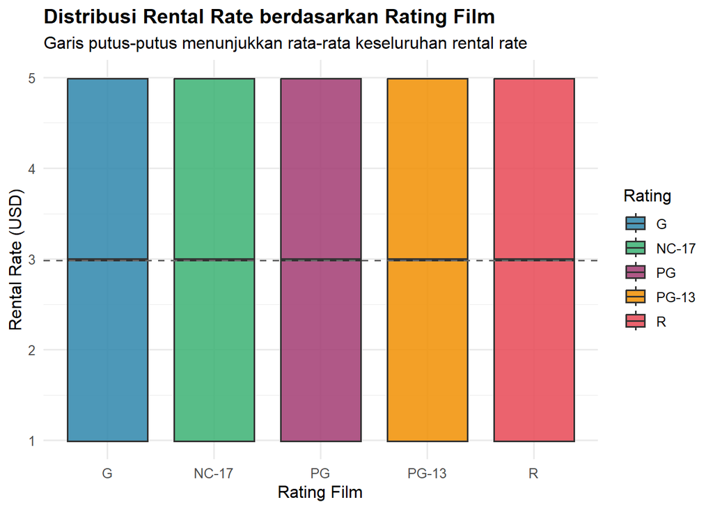

```r
ggplot(df, aes(x = rating, y = rental_rate, fill = rating)) +
  geom_boxplot(outlier.size  = 0.8,
               outlier.alpha = 0.4,
               alpha         = 0.85) +
  scale_fill_manual(values = c(
    "G"     = "#2E86AB",
    "PG"    = "#A23B72",
    "PG-13" = "#F18F01",
    "R"     = "#E84855",
    "NC-17" = "#3BB273"
  )) +
  geom_hline(yintercept = mean(df$rental_rate),
             linetype   = "dashed",
             color      = "gray40",
             linewidth  = 0.6) +
  labs(
    title    = "Distribusi Rental Rate berdasarkan Rating Film",
    subtitle = "Garis putus-putus menunjukkan rata-rata keseluruhan rental rate",
    x        = "Rating Film",
    y        = "Rental Rate (USD)",
    fill     = "Rating"
  ) +
  theme_minimal(base_size = 12) +
  theme(plot.title = element_text(face = "bold"))
```

# 4 Analisis Statistik

Analisis yang digunakan adalah **Regresi Linier Berganda** yang dijalankan secara terpisah untuk setiap segmen rating (*G*, *PG*, *PG-13*, *R*, dan *NC-17*), sehingga dapat dibandingkan besar dan arah pengaruh *Rental Duration* dan *Replacement Cost* terhadap *Rental Rate* di setiap segmen.

## 4.1 Model Regresi

$$\text{RentalRate}_i = \beta_0 + \beta_1
\cdot \text{RentalDuration}_i + \beta_2 \cdot \text{ReplacementCost}_i +
\varepsilon_i$$

di mana:

- $\beta_0$ = intersep (nilai *Rental Rate* ketika semua prediktor = 0)
- $\beta_1$ = koefisien regresi *Rental Duration*
- $\beta_2$ = koefisien regresi *Replacement Cost*
- $\varepsilon_i \sim \mathcal{N}(0, \sigma^2)$ = residual yang diasumsikan berdistribusi normal

## 4.2 Persiapan Data

```r
df_G     <- df %>% filter(rating == "G")
df_PG    <- df %>% filter(rating == "PG")
df_PG13  <- df %>% filter(rating == "PG-13")
df_R     <- df %>% filter(rating == "R")
df_NC17  <- df %>% filter(rating == "NC-17")

cat("Jumlah observasi G     :", nrow(df_G),    "\n")
```

```
## Jumlah observasi G     : 178
```

```r
cat("Jumlah observasi PG    :", nrow(df_PG),   "\n")
```

```
## Jumlah observasi PG    : 194
```

```r
cat("Jumlah observasi PG-13 :", nrow(df_PG13), "\n")
```

```
## Jumlah observasi PG-13 : 223
```

```r
cat("Jumlah observasi R     :", nrow(df_R),    "\n")
```

```
## Jumlah observasi R     : 195
```

```r
cat("Jumlah observasi NC-17 :", nrow(df_NC17), "\n")
```

```
## Jumlah observasi NC-17 : 210
```

## 4.3 Estimasi Model

### 4.3.1 Rating G

```r
model_G <- lm(rental_rate ~ rental_duration + replacement_cost, data = df_G)
summary(model_G)
```

```
##
## Call:
## lm(formula = rental_rate ~ rental_duration + replacement_cost,
##     data = df_G)
##
## Residuals:
##      Min       1Q   Median       3Q      Max
## -2.27988 -1.68748  0.06753  1.81888  2.62699
##
## Coefficients:
##                  Estimate Std. Error t value Pr(>|t|)
## (Intercept)       4.00824    0.56222   7.129 2.55e-11 ***
## rental_duration  -0.10971    0.08414  -1.304    0.194
## replacement_cost -0.02925    0.01910  -1.532    0.127
## ---
## Signif. codes:  0 '***' 0.001 '**' 0.01 '*' 0.05 '.' 0.1 ' ' 1
##
## Residual standard error: 1.627 on 175 degrees of freedom
## Multiple R-squared:  0.02348,    Adjusted R-squared:  0.01232
## F-statistic: 2.104 on 2 and 175 DF,  p-value: 0.1251
```

**Interpretasi (Rating G):** Berdasarkan output di atas, koefisien *Rental Duration* sebesar $\hat{\beta}_1 = -0.1097$ menunjukkan bahwa setiap penambahan satu hari durasi sewa — dengan *Replacement Cost* dianggap konstan — dikaitkan dengan perubahan *Rental Rate* rata-rata sebesar $-0.1097$ USD, dan hasil ini tidak signifikan secara statistik ($p\text{-value} = 0.194$). Model ini mampu menjelaskan $2.35\%$ variasi *Rental Rate* pada segmen G ($R^2 = 0.0235$).

### 4.3.2 Rating PG

```r
model_PG <- lm(rental_rate ~ rental_duration + replacement_cost, data = df_PG)
summary(model_PG)
```

```
##
## Call:
## lm(formula = rental_rate ~ rental_duration + replacement_cost,
##     data = df_PG)
##
## Residuals:
##      Min       1Q   Median       3Q      Max
## -2.53209 -1.76785 -0.01934  1.73524  2.40392
##
## Coefficients:
##                  Estimate Std. Error t value Pr(>|t|)
## (Intercept)       1.95879    0.59555   3.289   0.0012 **
## rental_duration   0.15942    0.08137   1.959   0.0516 .
## replacement_cost  0.01492    0.02068   0.721   0.4715
## ---
## Signif. codes:  0 '***' 0.001 '**' 0.01 '*' 0.05 '.' 0.1 ' ' 1
##
## Residual standard error: 1.631 on 191 degrees of freedom
## Multiple R-squared:  0.02165,    Adjusted R-squared:  0.01141
## F-statistic: 2.114 on 2 and 191 DF,  p-value: 0.1236
```

**Interpretasi (Rating PG):** Pada segmen PG, koefisien *Rental Duration* sebesar $\hat{\beta}_1 = 0.1594$ dan koefisien *Replacement Cost* sebesar $\hat{\beta}_2 = 0.0149$. Model menjelaskan $2.17\%$ variasi *Rental Rate* ($R^2 = 0.0217$).

### 4.3.3 Rating PG-13

```r
model_PG13 <- lm(rental_rate ~ rental_duration + replacement_cost, data = df_PG13)
summary(model_PG13)
```

```
##
## Call:
## lm(formula = rental_rate ~ rental_duration + replacement_cost,
##     data = df_PG13)
##
## Residuals:
##      Min       1Q   Median       3Q      Max
## -2.21988 -1.94859 -0.04264  1.86847  2.13895
##
## Coefficients:
##                   Estimate Std. Error t value Pr(>|t|)
## (Intercept)      2.5827495  0.5474579   4.718 4.24e-06 ***
## rental_duration  0.0872655  0.0791865   1.102    0.272
## replacement_cost 0.0005426  0.0173906   0.031    0.975
## ---
## Signif. codes:  0 '***' 0.001 '**' 0.01 '*' 0.05 '.' 0.1 ' ' 1
##
## Residual standard error: 1.641 on 220 degrees of freedom
## Multiple R-squared:  0.005493,   Adjusted R-squared:  -0.003548
## F-statistic: 0.6075 on 2 and 220 DF,  p-value: 0.5456
```

**Interpretasi (Rating PG-13):** Pada segmen PG-13, koefisien *Rental Duration* sebesar $\hat{\beta}_1 = 0.0873$ dan koefisien *Replacement Cost* sebesar $\hat{\beta}_2 = 5\times 10^{-4}$. Model menjelaskan $0.55\%$ variasi *Rental Rate* ($R^2 = 0.0055$).

### 4.3.4 Rating R

```r
model_R <- lm(rental_rate ~ rental_duration + replacement_cost, data = df_R)
summary(model_R)
```

```
##
## Call:
## lm(formula = rental_rate ~ rental_duration + replacement_cost,
##     data = df_R)
##
## Residuals:
##      Min       1Q   Median       3Q      Max
## -2.09085 -1.90233  0.05158  1.97997  2.19841
##
## Coefficients:
##                   Estimate Std. Error t value Pr(>|t|)
## (Intercept)       2.866111   0.616537   4.649  6.2e-06 ***
## rental_duration   0.046483   0.087136   0.533    0.594
## replacement_cost -0.007381   0.020747  -0.356    0.722
## ---
## Signif. codes:  0 '***' 0.001 '**' 0.01 '*' 0.05 '.' 0.1 ' ' 1
##
## Residual standard error: 1.674 on 192 degrees of freedom
## Multiple R-squared:  0.002235,   Adjusted R-squared:  -0.008159
## F-statistic: 0.215 on 2 and 192 DF,  p-value: 0.8067
```

**Interpretasi (Rating R):** Pada segmen R, koefisien *Rental Duration* sebesar $\hat{\beta}_1 = 0.0465$ dan koefisien *Replacement Cost* sebesar $\hat{\beta}_2 = -0.0074$. Model menjelaskan $0.22\%$ variasi *Rental Rate* ($R^2 = 0.0022$).

### 4.3.5 Rating NC-17

```r
model_NC17 <- lm(rental_rate ~ rental_duration + replacement_cost, data = df_NC17)
summary(model_NC17)
```

```
##
## Call:
## lm(formula = rental_rate ~ rental_duration + replacement_cost,
##     data = df_NC17)
##
## Residuals:
##      Min       1Q   Median       3Q      Max
## -2.37282 -1.81626  0.04014  1.81921  2.38852
##
## Coefficients:
##                  Estimate Std. Error t value Pr(>|t|)
## (Intercept)       3.85278    0.57157   6.741 1.54e-10 ***
## rental_duration  -0.04503    0.08361  -0.539    0.591
## replacement_cost -0.03229    0.01931  -1.672    0.096 .
## ---
## Signif. codes:  0 '***' 0.001 '**' 0.01 '*' 0.05 '.' 0.1 ' ' 1
##
## Residual standard error: 1.655 on 207 degrees of freedom
## Multiple R-squared:  0.01532,    Adjusted R-squared:  0.005809
## F-statistic: 1.611 on 2 and 207 DF,  p-value: 0.2023
```

**Interpretasi (Rating NC-17):** Pada segmen NC-17, koefisien *Rental Duration* sebesar $\hat{\beta}_1 = -0.045$ dan koefisien *Replacement Cost* sebesar $\hat{\beta}_2 = -0.0323$. Model menjelaskan $1.53\%$ variasi *Rental Rate* ($R^2 = 0.0153$).

### 4.3.6 Perbandingan Koefisien Seluruh Rating

```r
models  <- list(G = model_G, PG = model_PG,
                `PG-13` = model_PG13, R = model_R, `NC-17` = model_NC17)

tbl_coef <- do.call(rbind, lapply(names(models), function(nm) {
  m  <- models[[nm]]
  sm <- summary(m)$coefficients
  data.frame(
    Rating    = nm,
    Intercept = round(sm["(Intercept)",      "Estimate"],  4),
    Beta_RD   = round(sm["rental_duration",  "Estimate"],  4),
    pval_RD   = round(sm["rental_duration",  "Pr(>|t|)"],  4),
    Beta_RC   = round(sm["replacement_cost", "Estimate"],  4),
    pval_RC   = round(sm["replacement_cost", "Pr(>|t|)"],  4),
    R2        = round(summary(m)$r.squared,                4)
  )
}))

kable(tbl_coef,
      caption   = "Perbandingan Koefisien Regresi Berdasarkan Rating Film",
      col.names = c("Rating", "β₀ (Intercept)",
                    "β₁ Rental Duration", "p-value",
                    "β₂ Replacement Cost", "p-value", "R²")) %>%
  kable_styling(bootstrap_options = c("striped", "hover"), full_width = FALSE)
```

Perbandingan Koefisien Regresi Berdasarkan Rating Film

| Rating | β₀ (Intercept) | β₁ Rental Duration | p-value | β₂ Replacement Cost | p-value | R² |
| --- | --- | --- | --- | --- | --- | --- |
| G | 4.0082 | -0.1097 | 0.1940 | -0.0293 | 0.1274 | 0.0235 |
| PG | 1.9588 | 0.1594 | 0.0516 | 0.0149 | 0.4715 | 0.0217 |
| PG-13 | 2.5827 | 0.0873 | 0.2717 | 0.0005 | 0.9751 | 0.0055 |
| R | 2.8661 | 0.0465 | 0.5943 | -0.0074 | 0.7224 | 0.0022 |
| NC-17 | 3.8528 | -0.0450 | 0.5907 | -0.0323 | 0.0960 | 0.0153 |

## 4.4 Uji Asumsi Klasik

### 4.4.1 Uji Normalitas Residual (Shapiro-Wilk)

**Hipotesis:**

- $H_0$ : Residual berdistribusi normal
- $H_1$ : Residual tidak berdistribusi normal

Taraf signifikansi: $\alpha = 0.05$

```r
sw_results <- lapply(models, function(m) shapiro.test(m$residuals))

for (nm in names(sw_results)) {
  cat("Rating", nm)
  print(sw_results[[nm]])
  cat("\n")
}
```

```
## Rating G
##  Shapiro-Wilk normality test
##
## data:  m$residuals
## W = 0.89122, p-value = 4.058e-10
##
##
## Rating PG
##  Shapiro-Wilk normality test
##
## data:  m$residuals
## W = 0.88656, p-value = 6.075e-11
##
##
## Rating PG-13
##  Shapiro-Wilk normality test
##
## data:  m$residuals
## W = 0.84197, p-value = 2.519e-14
##
##
## Rating R
##  Shapiro-Wilk normality test
##
## data:  m$residuals
## W = 0.81833, p-value = 2.505e-14
##
##
## Rating NC-17
##  Shapiro-Wilk normality test
##
## data:  m$residuals
## W = 0.86846, p-value = 1.653e-12
```

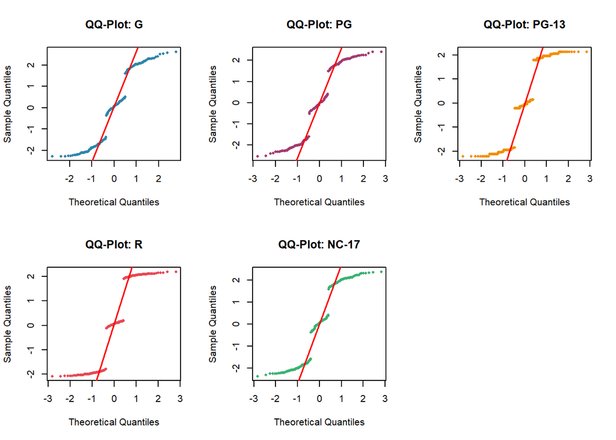

```r
par(mfrow = c(2, 3))

colors <- c(G = "#2E86AB", PG = "#A23B72", `PG-13` = "#F18F01",
            R = "#E84855", `NC-17` = "#3BB273")

for (nm in names(models)) {
  qqnorm(models[[nm]]$residuals,
         main = paste("QQ-Plot:", nm),
         col  = colors[nm], pch = 16, cex = 0.6)
  qqline(models[[nm]]$residuals, col = "red", lwd = 1.5)
}
par(mfrow = c(1, 1))
```

### 4.4.2 Uji Heteroskedastisitas (Breusch-Pagan)

**Hipotesis:**

- $H_0$ : Tidak terdapat heteroskedastisitas (variansi residual homogen)
- $H_1$ : Terdapat heteroskedastisitas

```r
bp_results <- lapply(models, function(m) bptest(m))

for (nm in names(bp_results)) {
  cat("Rating", nm)
  print(bp_results[[nm]])
  cat("\n")
}
```

```
## Rating G
##  studentized Breusch-Pagan test
##
## data:  m
## BP = 1.534, df = 2, p-value = 0.4644
##
##
## Rating PG
##  studentized Breusch-Pagan test
##
## data:  m
## BP = 2.004, df = 2, p-value = 0.3671
##
##
## Rating PG-13
##  studentized Breusch-Pagan test
##
## data:  m
## BP = 3.8576, df = 2, p-value = 0.1453
##
##
## Rating R
##  studentized Breusch-Pagan test
##
## data:  m
## BP = 2.445, df = 2, p-value = 0.2945
##
##
## Rating NC-17
##  studentized Breusch-Pagan test
##
## data:  m
## BP = 1.2572, df = 2, p-value = 0.5333
```

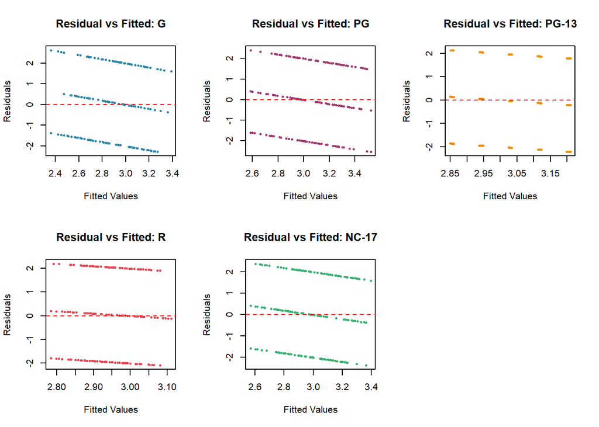

```r
par(mfrow = c(2, 3))

for (nm in names(models)) {
  plot(models[[nm]]$fitted.values, models[[nm]]$residuals,
       main = paste("Residual vs Fitted:", nm),
       xlab = "Fitted Values",
       ylab = "Residuals",
       col  = colors[nm], pch = 16, cex = 0.5)
  abline(h = 0, col = "red", lty = 2)
}
par(mfrow = c(1, 1))
```

**Interpretasi:** Uji Breusch-Pagan menguji apakah variansi residual bersifat konstan di sepanjang nilai prediksi. Apabila $p\text{-value} < 0.05$, maka $H_0$ ditolak dan terdapat indikasi **heteroskedastisitas**. Dari plot *Residual vs Fitted* di atas, dapat diamati pola sebaran residual di setiap segmen rating. Kondisi heteroskedastisitas — jika ada — umum terjadi pada data harga bisnis dengan rentang nilai yang bervariasi, dan perlu dicatat sebagai keterbatasan model bahwa estimasi *standard error* koefisien mungkin kurang efisien.

### 4.4.3 Uji Multikolinearitas (VIF)

Nilai *Variance Inflation Factor* (VIF) $> 10$ mengindikasikan multikolinearitas serius.

```r
for (nm in names(models)) {
  cat("VIF Rating", nm)
  print(vif(models[[nm]]))
  cat("\n")
}
```

```
## VIF Rating G rental_duration replacement_cost
##         1.001504         1.001504
##
## VIF Rating PG rental_duration replacement_cost
##         1.002523         1.002523
##
## VIF Rating PG-13 rental_duration replacement_cost
##         1.000031         1.000031
##
## VIF Rating R rental_duration replacement_cost
##         1.002235         1.002235
##
## VIF Rating NC-17 rental_duration replacement_cost
##         1.004539         1.004539
```

**Interpretasi:** Nilai VIF yang berada di bawah 10 untuk seluruh segmen rating mengindikasikan bahwa **tidak terdapat masalah multikolinearitas** yang serius antara *Rental Duration* dan *Replacement Cost*. Kedua prediktor dapat dipertahankan dalam model secara bersama-sama.

# 5 Kesimpulan

```r
dbDisconnect(con)
```